# Homework #4: Classification

Jie Tang

Due: Tue Mar 1 | 10:30 am

**SYS 4582/6018 | Spring 2022 | University of Virginia**

# Required R packages and Directories

```r
#data.dir = 'https://mdporter.github.io/SYS6018/data/' # data directory
library(glmnet)    # for glmnet() functions
library(yardstick) # for evaluation metrics
library(R6018)     # functions for SYS-6018
library(tidyverse) # functions for data manipulation
```

# Crime Linkage

Crime linkage attempts to determine if two or more unsolved crimes share a common offender. *Pairwise* crime linkage is the more simple task of deciding if two crimes share a common offender; it can be considered a binary classification problem. The linkage training data has 8 evidence variables that measure the similarity between a pair of crimes:

- `spatial` is the spatial distance between the crimes
- `temporal` is the fractional time (in days) between the crimes
- `tod` and `dow` are the differences in time of day and day of week between the crimes
- `LOC`, `POA,` and `MOA` are binary with a 1 corresponding to a match (type of property, point of entry, method of entry)
- `TIMERANGE` is the time between the earliest and latest possible times the crime could have occurred (because the victim was away from the house during the crime).
- The response variable indicates if the crimes are linked ($y=1$) or unlinked ($y=0$).

These problems use the [linkage-train](https://mdporter.github.io/SYS6018/data/linkage_train.csv) and [linkage-test](https://mdporter.github.io/SYS6018/data/linkage_test.csv) datasets (click on links for data).

```r
#setwd("C:/Users/tjj/Desktop/uva/Data mining")
data_train = read.csv('linkage_train.csv')
data_test = read.csv('linkage_test.csv')
head(data_train)
```

|  | spatial | temporal | tod | dow | LOC | POA | MOA | TIMERANGE | y |
| --- | --- | --- | --- | --- | --- | --- | --- | --- | --- |
| 1 | 0.3134 | 11.55 | 8.477 | 2.0919 | 1 | 0 | 1 | 10.00 | 1 |
| 2 | 33.6352 | 31.28 | 6.170 | 3.0718 | 0 | 0 | 0 | 18.33 | 0 |
| 3 | 25.4918 | 69.59 | 9.917 | 0.1736 | 0 | 1 | 0 | 0.00 | 0 |
| 4 | 28.1003 | 22.85 | 3.530 | 1.5378 | 0 | 0 | 1 | 8.00 | 0 |
| 5 | 4.4607 | 53.82 | 4.508 | 3.0978 | 0 | 0 | 0 | 12.00 | 0 |
| 6 | 18.1486 | 53.94 | 1.350 | 2.1125 | 0 | 0 | 0 | 0.00 | 0 |

# Problem 1: Penalized Regression for Crime Linkage

## a. Fit a penalized *linear regression* model to predict linkage. Use a lasso, ridge, or elasticnet penalty (your choice).

- Report the value of $\alpha$ used (if elasticnet)
- Report the value of $\lambda$ used
- Report the estimated coefficients

```r
X = makeX(select(data_train, spatial, temporal, tod, dow, LOC, POA, MOA, TIMERANGE))
Y = data_train$y
#linear regression
ridge_cv <- cv.glmnet(X, Y, alpha = 0,
                      standardize = TRUE, nfolds = 10)


lambda_cv <- ridge_cv$lambda.min

# Fit final model, get its sum of squared
# residuals and multiple R-squared
model_cv <- glmnet(X, Y, alpha = 0, lambda = lambda_cv,
                   standardize = TRUE)
as.matrix(coef(model_cv))
```

```
#>                     s0
#> (Intercept)  9.263e-02
#> spatial     -2.319e-03
#> temporal    -1.548e-04
#> tod         -2.213e-03
#> dow         -5.795e-03
#> LOC          4.263e-02
#> POA          9.321e-03
#> MOA          7.297e-03
#> TIMERANGE    2.499e-05
```

```r
betas <- as.vector((as.matrix(coef(model_cv))[-1, ]))
```

## b. Fit a penalized *logistic regression* model to predict linkage. Use a lasso, ridge, or elasticnet penalty (your choice).

- Report the value of $\alpha$ used (if elasticnet)
- Report the value of $\lambda$ used
- Report the estimated coefficients

```r
#linear regression
log_ridge_cv <- cv.glmnet(X, Y, alpha = 0,
                      standardize = TRUE, nfolds = 10, family="binomial")


lambda_cv <- log_ridge_cv$lambda.min

# Fit final model, get its sum of squared
# residuals and multiple R-squared
log_model_cv <- glmnet(X, Y, alpha = 0, lambda = lambda_cv,
                   standardize = TRUE, family="binomial")
as.matrix(coef(log_model_cv))
```

```
#>                     s0
#> (Intercept) -0.8373406
#> spatial     -0.1723809
#> temporal    -0.0096617
#> tod         -0.1027666
#> dow         -0.2417616
#> LOC          1.3616802
#> POA          0.4182149
#> MOA          0.2318396
#> TIMERANGE    0.0005417
```

```r
betas <- as.vector((as.matrix(coef(log_model_cv))[-1, ]))
```

## c. Produce one plot that has the ROC curves, using the *training data*, for both models (from part a and b). Use color and/or linetype to distinguish between models and include a legend.

```r
linear_p.hat = predict(model_cv, X, type = 'response')
linear_gamma = predict(model_cv, X, type = 'link')
log_p.hat = predict(log_model_cv, X, type='response')
log_gamma = predict(log_model_cv, X, type='link')


perf = tibble(truth = Y, linear_gamma, linear_p.hat) %>%
  #- group_by() + summarize() in case of ties
  group_by(linear_gamma, linear_p.hat) %>%
  summarize(n=n(), n.1=sum(truth), n.0=n-sum(truth)) %>% ungroup() %>%
  #- calculate metrics
  arrange(linear_gamma) %>%
  mutate(FN = cumsum(n.1),    # false negatives
         TN = cumsum(n.0),    # true negatives
         TP = sum(n.1) - FN,  # true positives
         FP = sum(n.0) - TN,  # false positives
         N = cumsum(n),       # number of cases predicted to be 1
         TPR = TP/sum(n.1), FPR = FP/sum(n.0)) %>%
  #- only keep relevant metrics
  select(-n, -n.1, -n.0, linear_gamma, linear_p.hat)
log_perf = tibble(truth = Y, log_gamma, log_p.hat) %>%
  #- group_by() + summarize() in case of ties
  group_by(log_gamma, log_p.hat) %>%
  summarize(n=n(), n.1=sum(truth), n.0=n-sum(truth)) %>% ungroup() %>%
  #- calculate metrics
  arrange(log_gamma) %>%
  mutate(log_FN = cumsum(n.1),    # false negatives
         log_TN = cumsum(n.0),    # true negatives
         log_TP = sum(n.1) - log_FN,  # true positives
         log_FP = sum(n.0) - log_TN,  # false positives
         log_N = cumsum(n),       # number of cases predicted to be 1
         log_TPR = log_TP/sum(n.1), log_FPR = log_FP/sum(n.0)) %>%
  #- only keep relevant metrics
  select(-n, -n.1, -n.0, log_gamma, log_p.hat)
```

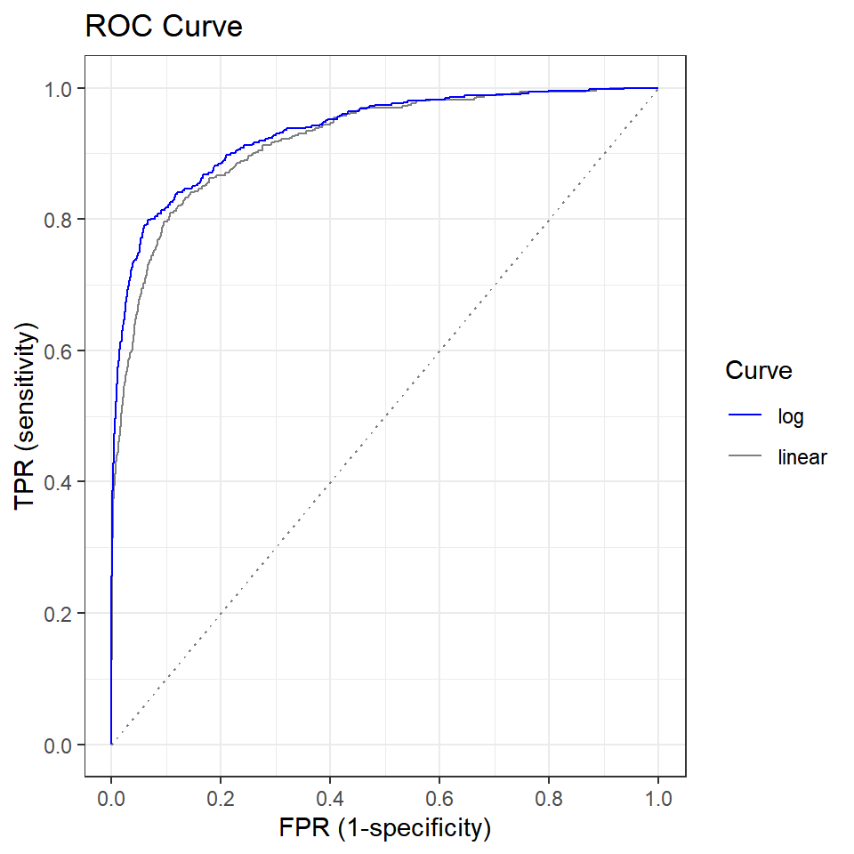

```r
#: Make ROC curve
perf %>% ggplot(aes(FPR, TPR)) + geom_path(aes(color='linear')) +
  geom_path(data = log_perf, aes(log_FPR, log_TPR, color='log'), color='blue') +
  geom_segment(x=0, xend=1, y=0, yend=1, lty=3) +
  labs(x='FPR (1-specificity)', y='TPR (sensitivity)') +
  geom_segment(x=0, xend=1, y=0, yend=1, lty=3, color='grey50') +
  scale_x_continuous(breaks = seq(0, 1, by=.20)) +
  scale_y_continuous(breaks = seq(0, 1, by=.20)) +
  scale_colour_manual(name='Curve',
                     breaks=c('log', 'linear'),
                     values = c('log'="blue", 'linear'="grey50")) +
  ggtitle("ROC Curve")
```

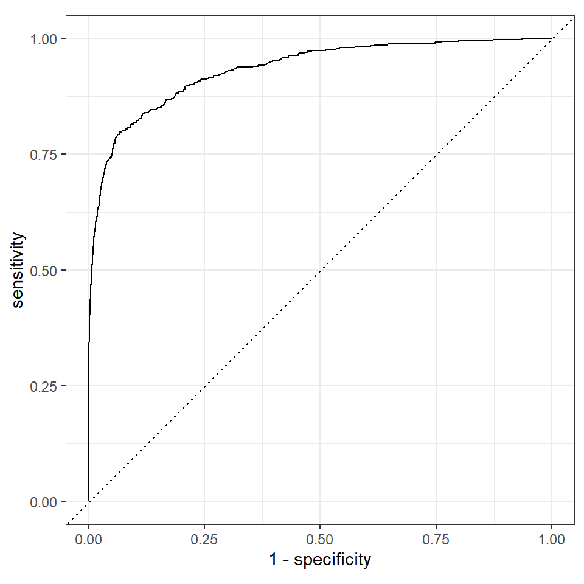

```r
#: ROC plots
library(yardstick)
test = tibble(truth = factor(Y, levels=c(1,0)), log_gamma[,1])
ROC = tibble(truth = factor(Y, levels=c(1,0)), g=log_gamma[,1]) %>%
  yardstick::roc_curve(truth, g)
autoplot(ROC) # autoplot() method
```